# Rt Correction and Feature definition

Pietro Franceschi | pietro.franceschi@fmach.it

```r
library(xcms)
library(MsExperiment)
library(Spectra)
library(tidyverse)
library(plotly)
```

## Introduction

In the previous demo we have been dealing with peak picking, so we assume that we have now a list of chromatographic peaks which have been detected across the full set of samples.

The next step in the process is to “match” these lists of peaks in a consensus list of **features** which will be the variables which will be present in the final data matrix.

This process of matching is necessary to compensate:

- measurement error in the m/z dimension
- retention time shifts

In general, the first phenomenon is less important than the second: when you buy a very expensive mass spectrometer, the instrument producer will do its best to keep *mass accuracy* as high as possible. On that dimension you, basically, do binning. Chromatographic stability, on the other hand, is by far less easy to control.

We start by reading in the peak picked data (saved at the end of the peak picking demo):

```r
load("wines.RData")
```

We already know that our dataset contains blank injections. They could be used to identify an exclusion list, but for now let’s take them out:

```r
## identify non blank indices
no_blank_id <- which(sampleData(raw_data)$variety != "blank")
## subset the data with a specific xcms function
raw_data <- filterFile(raw_data, file = no_blank_id)
## check the metadata (the descriptive columns)
sampleData(raw_data) |>
  as_tibble() |>
  dplyr::select(inj_ord, color, variety, bottle, rep)
```

```
## # A tibble: 26 × 5
##    inj_ord color variety bottle rep
##    <chr>   <chr> <chr>   <chr>  <chr>
##  1 x002    X     QC      X      1
##  2 x003    X     QC      X      2
##  3 x004    red   sangio  B      1
##  4 x005    red   ptnoir  A      1
##  5 x006    red   merlot  A      1
##  6 x007    wht   vermen  A      1
##  7 x008    red   cannon  A      1
##  8 x009    wht   chardo  B      1
##  9 x010    wht   chardo  A      1
## 10 x011    red   lagrei  B      1
## # ℹ 16 more rows
```

Let’s now visualize the amount of retention time shift looking at the ion trace of a compound which should be present in almost all samples:

```r
# extract the chromatogram
chr_raw <- chromatogram(raw_data,
                        mz = 295.0445 + 0.01*c(-1, 1),
                        rt = 250 + 20*c(-1, 1),
                        include = "none")
```

`chromatogram()` always reads the raw data; the `include = "none"` argument tells xcms not to attach to the result the chromatographic peaks detected in that region (we look for them by hand below).

Let’s find the chromatographic peaks in the slice:

```r
sub_peaks <- chromPeaks(raw_data) |>
  as_tibble() |>
  filter(between(mz, 295.03,295.05)) |>
  filter(between(rt, 230,270))
```

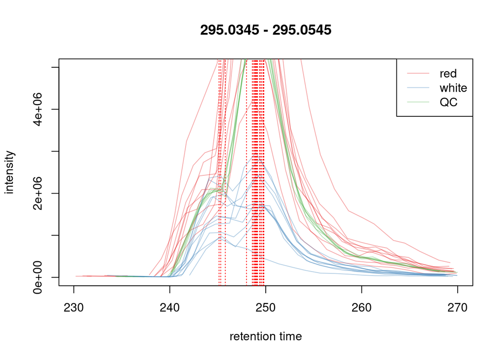

```r
library(RColorBrewer)
group_colors <- paste0(brewer.pal(3, "Set1"), "60")
names(group_colors) <- c("red","wht","X")
plot(chr_raw, col = group_colors[sampleData(raw_data)$color], ylim = c(0,5E6))
legend("topright", legend = c("red", "white", "QC"), col = group_colors, lty = 1)
abline(v = sub_peaks$rt, col = "red", lty = 3)
```

Here we have a tricky situation. The peaks are not aligned, even if the shift is really small, moreover this is actually a double feature, which is also potential biomarker for color and variety … so we should go back to peak detection and play around ;-) to be able to identify the two peaks.

Anyway, let’s try to correct the RT shift. As usual in xcms this can be done in different ways, here we will use the most simple solution (a potentially more flexible one based on *dynamic time warping* is also available).

What we will do is to apply this algorithm on the QCs and then extrapolate the estimated RT correction on the samples. The rationale behind this choice is the following: samples could be chemically different so it could be in principle possible to misinterpret a chemical difference (which produces a difference in RT) with a retention time shift of analytical origin.

If I use QCs to do that the chemical nature of the samples is the same so every difference is coming from analytical drifts!

The idea behind retention time correction is quite simple:

- match groups of chromatographic peaks present in all samples (called house keeping peak groups)
- estimate a consensus retention time
- extrapolate/interpolate the retention time on regions of the RT axes where the peaks are not present (either with a linear or a loess function)

The first thing to do is to identify the house keeping groups:

The parameters here are:

- **sampleGroups** and **minFraction**: some peak could be missing in some sample, so a house keeping group could include fewer peaks than samples. The way to control that is to define groups of samples (`sampleGroups`) and to accept only the groups of peaks detected in at least a fraction (`minFraction`) of the samples of at least one group
- **binSize** is the width of the m/z slices
- **bw**: a density estimator is used to find the “correct” position of the peak along the RT dimension. This is the bandwidth (in seconds) of the density estimator.

```r
raw_data <- groupChromPeaks(
  raw_data,
  param = PeakDensityParam(sampleGroups = sampleData(raw_data)$color,
                           minFraction = 2/3,
                           binSize = 0.02,  ## width of the slices
                           bw = 3))  ## bandwidth of the density used to find the consensus position
```

After this grouping, the retention time correction is performed on the QCs only (`subset`):

```r
raw_data <- adjustRtime(
  raw_data,
  param = PeakGroupsParam(minFraction = 1,
                          subset = which(sampleData(raw_data)$variety == "QC"), span = 0.4))
```

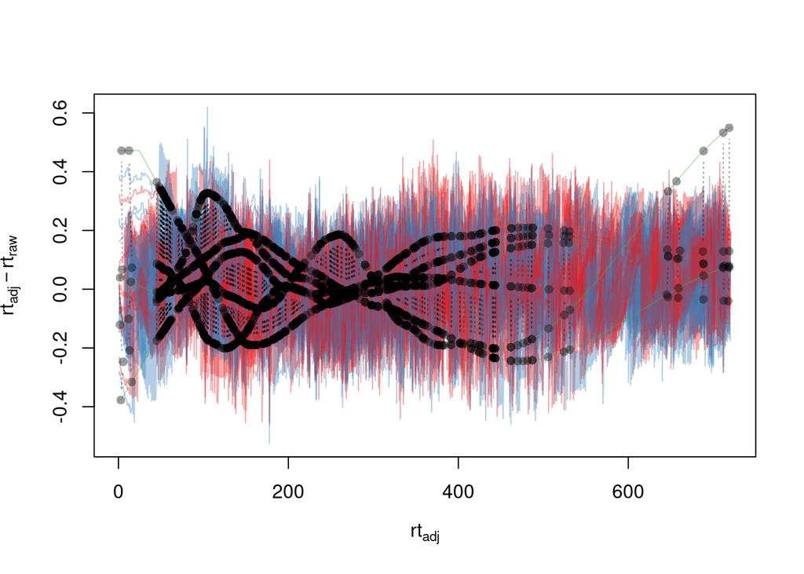

```r
plotAdjustedRtime(raw_data, col = group_colors[sampleData(raw_data)$color])
```

So the retention time correction here is really small, speaking of a remarkable analytical reproducibility. In general the reproducibility of the chromatography is considered good if the required shift is smaller than the typical chromatographic width. This is anyway a rule of thumb since everything is very much dependent on the analytical method. The black dots show the position of the housekeeping groups which were used to estimate the extent of retention time correction on the QCs.

After retention time correction is now time to move from *chromatographic peaks* to **features**. With this term we define a set of consensus groups of peaks which can be used reliably to measure the intensity of a given ion across all samples. If you look to the overall pre-processing from a distant perspective, what we have been basically doing is to try to compensate in a clever and intelligent way for mz inaccuracies and retention time shifts, and the core of the riddle is that the samples are actually (and luckily) different.

Features are obtained by a further grouping of the chromatographic peaks after retention time correction:

```r
raw_data <- groupChromPeaks(
  raw_data,
  param = PeakDensityParam(sampleGroups = sampleData(raw_data)$color,
                           minFraction = 2/3,
                           binSize = 0.02,  ## width of the slices
                           bw = 3))  ## bandwidth of the density used to find the consensus position
```

Let’s now look at their definition

```r
## extract them from the grouped data
features <- featureDefinitions(raw_data)
head(features)
```

```
##          mzmed    mzmin    mzmax     rtmed     rtmin     rtmax npeaks red wht X
## FT001 56.56990 56.56982 56.56991 274.05291 272.92031 275.30615      8   8   0 0
## FT002 59.01401 59.01395 59.01411  52.56501  51.36898  53.42346     17   6   6 5
## FT003 65.67792 65.67789 65.67797  61.27596  60.28428  69.03806     10   9   0 0
## FT004 65.67793 65.67791 65.67794  79.48278  78.58837  80.35275      9   9   0 0
## FT005 68.45647 68.45641 68.45649 182.16756 180.08132 183.31498     17   3   8 6
## FT006 68.45646 68.45642 68.45648 163.10147 161.28544 171.09788     10   2   2 6
##            peakidx ms_level
## FT001 1875, 25....        1
## FT002 405, 730....        1
## FT003 1546, 28....        1
## FT004 1545, 28....        1
## FT005 292, 101....        1
## FT006 293, 101....        1
```

The df is quite rich:

- rownames are the feature id
- mz* refer to the boundaries of the mz of the chromatographic peaks which were *grouped* in that feature
- rt* is the same but for retention time
- npeaks tell us how many chromatographic peaks were assigned to this feature
- the subsequent columns are giving you the same info split by sample group
- peakidx contains the index of peaks which were assigned to this feature

Let’s dig more into this. For example, can we visualize the position of the peaks assigned to FT005? The idx are the indexes of the rows in the peak table:

```r
idx_F005 <- features["FT005","peakidx"][[1]]
```

Let’s plot them across the retention time:

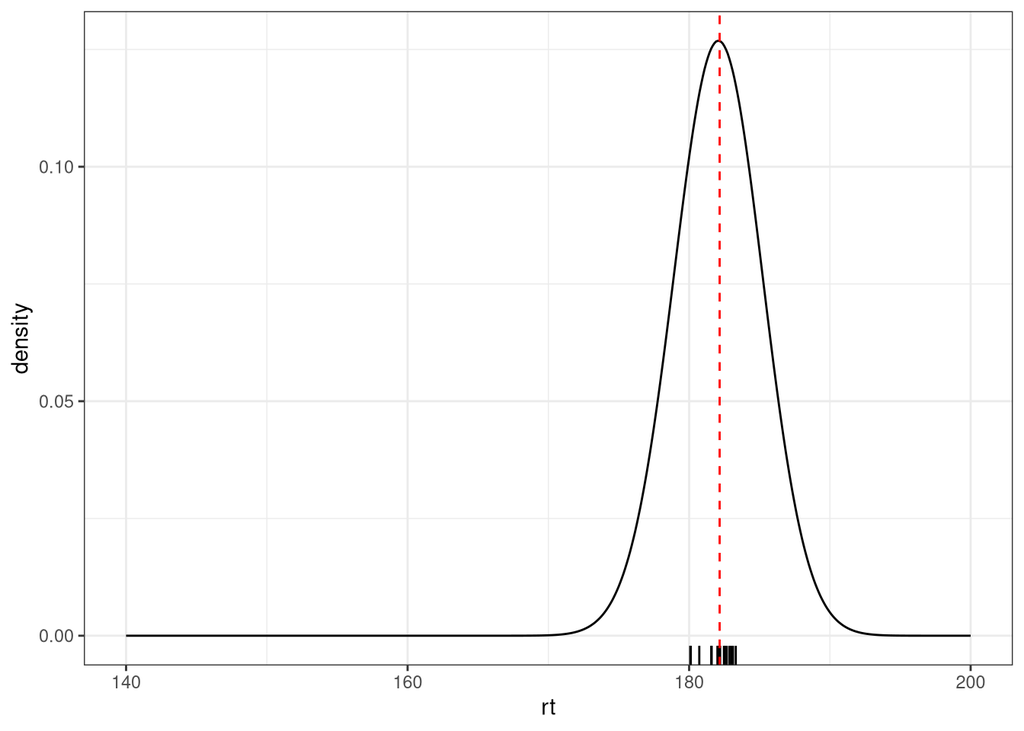

```r
chromPeaks(raw_data) |>
  as_tibble() |>
  slice(idx_F005) |>
  ggplot() +
  geom_density(aes(x = rt), bw = 3) +
  geom_rug(aes(x = rt)) +
  geom_vline(xintercept = features["FT005","rtmed"], col = "red", lty = 2) +
  xlim(140, 200) +
  theme_bw()
```

Here the rug shows the position of the chromatographic peaks, the line is the density profile (not a chromatographic trace!) and the red line is our best “estimate” of the true position of the feature

Ok now that we have the definition of the features, let’s get the final data matrix! Mind the gap! `xcms` returns the features in rows and the samples in columns, so the matrix is transposed with respect to the standard R shape (samples in rows): remember to transpose it (`t()`) before the statistical analysis.

```r
DM <- featureValues(raw_data, value = "into")
dim(DM)
```

```
## [1] 734  26
```

```r
## the first features in the first samples, with short sample names (just for display)
dm_corner <- DM[1:6, 1:6]
colnames(dm_corner) <- sampleData(raw_data)$inj_ord[1:6]
dm_corner
```

```
##           x002     x003      x004    x005    x006    x007
## FT001       NA       NA  716179.8 1131380 1035399      NA
## FT002 986147.4 975746.5  708724.8      NA  987357      NA
## FT003       NA       NA  475746.8      NA  717797      NA
## FT004       NA       NA  981039.5      NA 1070249      NA
## FT005 947277.0 802055.4 1505677.8      NA      NA 1066122
## FT006 438418.3 401059.7  614215.3      NA      NA      NA
```

Well … we see a lot of NAs there … Recalling what we discussed in the lecture, NAs can be there for two main reasons:

- a compound is below the detection limit in one or more samples. No compounds, no features, no party …
- our peak picking could have been mistaken somewhere

Anyway, `xcms` implements a clever strategy to try to fix, at least partially, the NAs. The function `fillChromPeaks` will take care of going back to the raw files and integrate the signal possibly present in the mz/rt region of each feature. If the peak was there and was missed by chance this will basically recover the lost signal.

```r
raw_data_filled <- fillChromPeaks(raw_data, param = ChromPeakAreaParam())
```

```r
DM <- featureValues(raw_data_filled, value = "into")
dm_corner <- DM[1:6, 1:6]
colnames(dm_corner) <- sampleData(raw_data_filled)$inj_ord[1:6]
dm_corner
```

```
##           x002     x003      x004      x005      x006      x007
## FT001 391819.0 565995.0  716179.8 1131380.1 1035399.5        NA
## FT002 986147.4 975746.5  708724.8  293215.3  987357.0  462625.1
## FT003 213597.5 199233.4  475746.8  139179.1  717797.0        NA
## FT004 580891.0 610839.2  981039.5  486248.4 1070248.7        NA
## FT005 947277.0 802055.4 1505677.8  409578.4  357077.7 1066122.2
## FT006 438418.3 401059.7  614215.3  308460.8  409266.0  454682.4
```

The definition of each feature can be extracted with a specific function:

```r
feat <- featureDefinitions(raw_data_filled)
as_tibble(feat, rownames = "feat_id")
```

```
## # A tibble: 734 × 13
##    feat_id mzmed mzmin mzmax rtmed rtmin rtmax npeaks   red   wht     X peakidx
##    <chr>   <dbl> <dbl> <dbl> <dbl> <dbl> <dbl>  <dbl> <dbl> <dbl> <dbl> <list>
##  1 FT001    56.6  56.6  56.6 274.  273.  275.       8     8     0     0 <dbl>
##  2 FT002    59.0  59.0  59.0  52.6  51.4  53.4     17     6     6     5 <dbl>
##  3 FT003    65.7  65.7  65.7  61.3  60.3  69.0     10     9     0     0 <dbl>
##  4 FT004    65.7  65.7  65.7  79.5  78.6  80.4      9     9     0     0 <dbl>
##  5 FT005    68.5  68.5  68.5 182.  180.  183.      17     3     8     6 <dbl>
##  6 FT006    68.5  68.5  68.5 163.  161.  171.      10     2     2     6 <dbl>
##  7 FT007    69.2  69.2  69.2 205.  195.  207.       8     7     0     0 <dbl>
##  8 FT008    71.0  71.0  71.0 153.  152.  154.      17     1    10     6 <dbl>
##  9 FT009    71.0  71.0  71.0  56.6  56.0  57.2     16     1     9     6 <dbl>
## 10 FT010    73.0  73.0  73.0  75.0  74.1  76.3     21     9     7     5 <dbl>
## # ℹ 724 more rows
## # ℹ 1 more variable: ms_level <int>
```

The situation improved, but it is not yet perfect.

We now save the output which will be used for the subsequent statistical analysis and compound annotation:

```r
save(raw_data_filled, DM, feat, file = "processed_wines_data.RData")
```

## Checking Feature chromatograms

A typical thing one wants to do at some point in the analysis is to check if the chromatographic peaks of a really interesting feature are really there …

In order to do that `xcms` provides a really handy function:

```r
ft_chr1 <- featureChromatograms(raw_data_filled,
                                features = "FT005",
                                expandRt = 15,
                                filled = TRUE)
```

Now we plot it highlighting the integrated areas and the class of the samples:

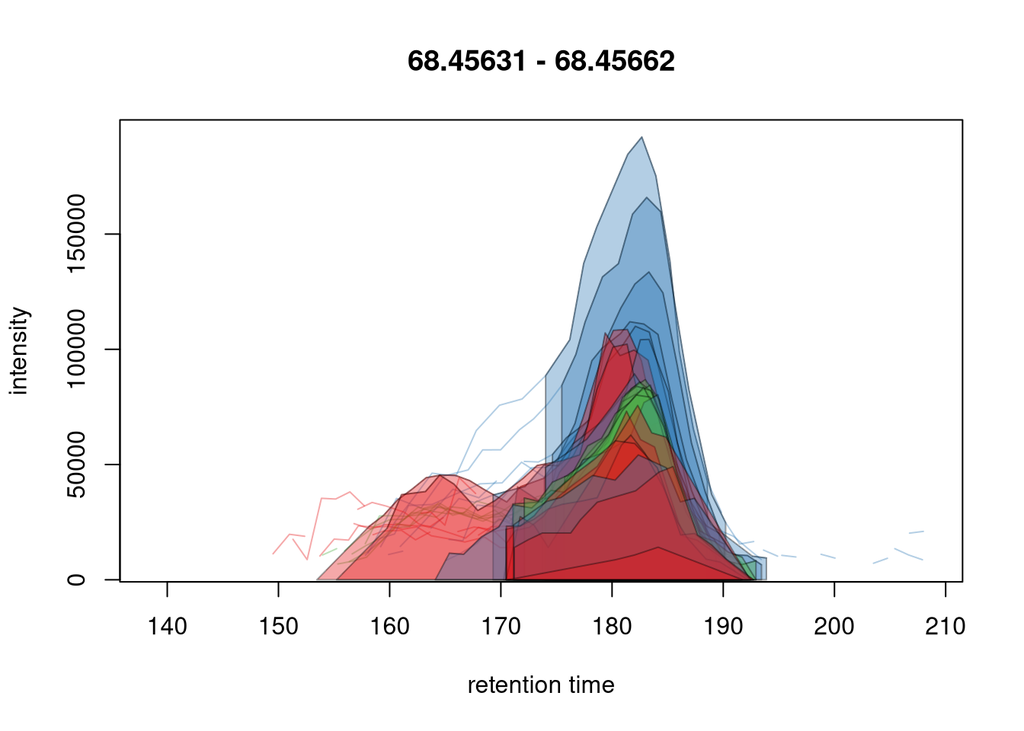

```r
sample_colors <- group_colors[sampleData(raw_data_filled)$color]
plot(ft_chr1, col = sample_colors,
     peakBg = sample_colors[chromPeaks(ft_chr1)[, "sample"]])
```

That can be used to spot problems of integration, and, also, if a biomarker is really a biomarker ;-)

## Feature Quality Assessment

As we stressed along the full lecture, the best way to validate the outcomes of your analysis is to go back to the raw data and inspect the extracted ion traces. However it would be useful to get an overall feedback on “quality” of each feature.

`xcms` already implements some useful tools to do that:

```r
head(featureSummary(raw_data_filled))
```

```
##       count     perc multi_count multi_perc       rsd
## FT001     8 30.76923           0    0.00000 0.4176693
## FT002    17 65.38462           0    0.00000 0.1798341
## FT003     9 34.61538           1   11.11111 0.6343434
## FT004     9 34.61538           0    0.00000 0.5146304
## FT005    17 65.38462           0    0.00000 0.3213700
## FT006    10 38.46154           0    0.00000 0.3302743
```

Here we see:

- **counts**: number of chromatographic peaks associated to each feature
- **perc**: percentage of samples in which a peak was found
- **multi_count**: number of samples in which more than one peak was assigned to the feature
- **rsd**: relative standard deviation of the feature intensity

This can be also split by sample class:

```r
sample_vs_qc <- ifelse(sampleData(raw_data_filled)$variety == "QC","QC","S")

featureSummary(raw_data_filled, group = sample_vs_qc, skipFilled = FALSE) |>
  as_tibble(rownames = "feat_id") |>
  arrange(desc(QC_rsd))
```

```
## # A tibble: 734 × 16
##    feat_id count  perc multi_count multi_perc   rsd QC_count QC_perc
##    <chr>   <dbl> <dbl>       <dbl>      <dbl> <dbl>    <dbl>   <dbl>
##  1 FT341      21  80.8           0       0    1.03         6   100
##  2 FT046      26 100             3      11.5  0.747        6   100
##  3 FT084      26 100             4      15.4  0.880        6   100
##  4 FT411      19  73.1           0       0    0.902        6   100
##  5 FT198      26 100             3      11.5  0.806        6   100
##  6 FT501      23  88.5           1       4.35 1.30         6   100
##  7 FT232      26 100             3      11.5  0.776        6   100
##  8 FT481      14  53.8           0       0    0.582        4    66.7
##  9 FT251      26 100             3      11.5  0.747        6   100
## 10 FT045      26 100            14      53.8  0.467        6   100
## # ℹ 724 more rows
## # ℹ 8 more variables: QC_multi_count <dbl>, QC_multi_perc <dbl>, QC_rsd <dbl>,
## #   S_count <dbl>, S_perc <dbl>, S_multi_count <dbl>, S_multi_perc <dbl>,
## #   S_rsd <dbl>
```

```r
featureSummary(raw_data_filled, group = sample_vs_qc, skipFilled = FALSE) |>
  as_tibble(rownames = "feat_id") |>
  filter(S_rsd < QC_rsd)
```

```
## # A tibble: 17 × 16
##    feat_id count  perc multi_count multi_perc   rsd QC_count QC_perc
##    <chr>   <dbl> <dbl>       <dbl>      <dbl> <dbl>    <dbl>   <dbl>
##  1 FT013      26 100             0       0    0.239        6   100
##  2 FT015      26 100            25      96.2  0.490        6   100
##  3 FT040      26 100             0       0    0.187        6   100
##  4 FT042      26 100             2       7.69 0.218        6   100
##  5 FT045      26 100            14      53.8  0.467        6   100
##  6 FT046      26 100             3      11.5  0.747        6   100
##  7 FT084      26 100             4      15.4  0.880        6   100
##  8 FT118      26 100             0       0    0.287        6   100
##  9 FT183      26 100            18      69.2  0.344        6   100
## 10 FT185      26 100             3      11.5  0.174        6   100
## 11 FT198      26 100             3      11.5  0.806        6   100
## 12 FT265      26 100            26     100    0.400        6   100
## 13 FT266      26 100             3      11.5  0.311        6   100
## 14 FT341      21  80.8           0       0    1.03         6   100
## 15 FT411      19  73.1           0       0    0.902        6   100
## 16 FT481      14  53.8           0       0    0.582        4    66.7
## 17 FT533      26 100             1       3.85 0.261        6   100
## # ℹ 8 more variables: QC_multi_count <dbl>, QC_multi_perc <dbl>, QC_rsd <dbl>,
## #   S_count <dbl>, S_perc <dbl>, S_multi_count <dbl>, S_multi_perc <dbl>,
## #   S_rsd <dbl>
```

This is useful to filter out features with a higher variability in the QCs than in the samples. But …

- markers of variety can suffer from dilution effects in the pooled QC
- variety specific QCs! … but then the number of injections explodes

## Something for you!

1. In the first demo (inspecting the raw data) we looked at the extracted ion trace around m/z 289.07, which showed two peaks. How many features were defined there? Were the peaks integrated well?
2. If you go back to the feature table, you will see that in some cases the number of peaks assigned to a feature can be larger than the number of samples. How can this be? Look at the extracted ion traces and try to understand what happens (ADVANCED)

## A possible solution

**1.** The features in the m/z slice of the ion

```r
ft_289 <- feat |>
  as_tibble(rownames = "feat_id") |>
  filter(between(mzmed, 289.06, 289.08)) |>
  dplyr::select(feat_id, mzmed, rtmed, npeaks)

ft_289
```

```
## # A tibble: 3 × 4
##   feat_id mzmed rtmed npeaks
##   <chr>   <dbl> <dbl>  <dbl>
## 1 FT370    289.  249.     24
## 2 FT371    289.  278.     22
## 3 FT372    289.  234.     14
```

and their chromatograms, with the integrated areas

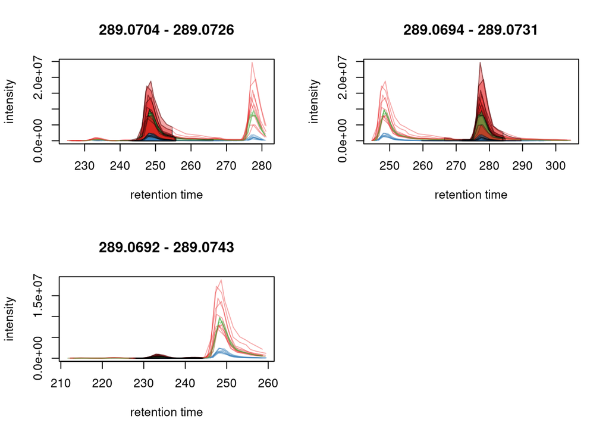

```r
ft_289_chr <- featureChromatograms(raw_data_filled, features = ft_289$feat_id,
                                   expandRt = 15, filled = TRUE)
plot(ft_289_chr, col = sample_colors,
     peakBg = sample_colors[chromPeaks(ft_289_chr)[, "sample"]])
```

3 features were defined in the slice: the two main peaks we saw in the first demo (around 249 s and 278 s) became two separate features, and a third one corresponds to a small peak at about 234 s. The integration looks good. Note also the colors: the signal is much higher in the red wines than in the white ones, with the QCs in between … as expected for catechin and epicatechin, which come from the skins and the seeds of the grapes.

**2.** The features with more peaks than samples

```r
n_samples <- nrow(sampleData(raw_data_filled))

feat |>
  as_tibble(rownames = "feat_id") |>
  filter(npeaks > n_samples) |>
  dplyr::select(feat_id, mzmed, rtmed, npeaks)
```

```
## # A tibble: 53 × 4
##    feat_id mzmed rtmed npeaks
##    <chr>   <dbl> <dbl>  <dbl>
##  1 FT015    97.0  51.4     79
##  2 FT019   103.  101.      27
##  3 FT033   114.  137.      27
##  4 FT034   115.   56.3     27
##  5 FT041   117.  618.      33
##  6 FT043   117.  700.      30
##  7 FT045   117.  671.      35
##  8 FT058   125.   53.5     72
##  9 FT064   128.   61.4     27
## 10 FT065   129.   61.5     28
## # ℹ 43 more rows
```